# Vue Statistique de notre base de donnés

## I - Répartition des dignités au sein des tenrac

Étant donné que les dignités indiquent une hiérarchie, nous avons trouvé judicieux de la montrer en mettant en valeur le fait qu'il existe plusieurs niveaux plus ou moins accessibles.

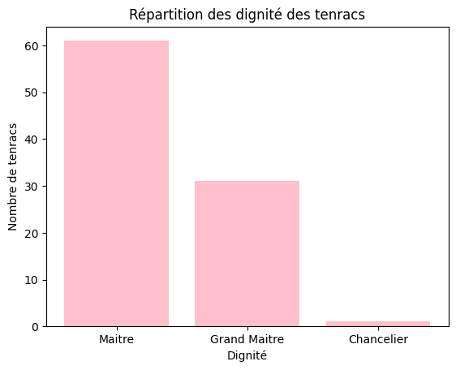

```python
import pandas
import matplotlib.pyplot as plt

def get_occur(d):
    r = {}
    for element in d:
        if element not in r:
            r[element] = 1
        else:
            r[element] += 1
    return r

table1 = pandas.read_csv("csv_output/Dignite.csv")
table1 = table1['nom_dignite'].tolist()
resultat = get_occur(table1)

x = list(resultat.keys())
y = list(resultat.values())

plt.title("Répartition des dignité des tenracs")
plt.xlabel('Dignité')
plt.ylabel('Nombre de tenracs')

plt.bar(x,y,align='center', color='pink')
plt.show()
```

On constate que la dignité de Maitre est la plus répandue de loin, cepandant on peut aussi remarquer qu'il n'y a qu'un seul chancelier, ce qui est normal car il s'agit d'un chef.

## II - Répartition des titres au sein des tenrac

Les titres démontrent la capacité des tenracs à s'investir dans leur mouvement, on peut observer leur répartition pour dresser un portrait de l'activité des tenracs.

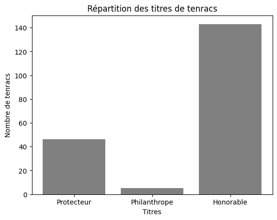

```python
import pandas
import matplotlib.pyplot as plt

def get_occur(d):
    r = {}
    for element in d:
        if element not in r:
            r[element] = 1
        else:
            r[element] += 1
    return r

table1 = pandas.read_csv("csv_output/Titre.csv")
table1 = table1['nom_titre'].tolist()
resultat = get_occur(table1)

x = list(resultat.keys())
y = list(resultat.values())

plt.title("Répartition des titres de tenracs")
plt.xlabel('Titres')
plt.ylabel('Nombre de tenracs')

plt.bar(x,y,align='center', color='gray')
plt.show()
```

On constate que d'après le graphique en barres, le titre le plus répandu au sein de la population tenrac est "Honorable". On peut en conclure que ce titre est le plus accessible.

## III - Répartition des tenracs au sein des clubs

Sachant que les clubs font partie intégrante de la vie des tenracs, il est intéréssant de regarder les plus populaires en fonction de leurs nombre de membres pour se donner une idée de leur importance.

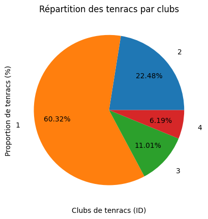

```python
import pandas
import matplotlib.pyplot as plt

def get_occur(d):
    r = {}
    for element in d:
        if element not in r:
            r[element] = 1
        else:
            r[element] += 1
    return r

table1 = pandas.read_csv("csv_output/TenracClub.csv")
table1 = table1['id_club'].tolist()
resultat = get_occur(table1)

x = list(resultat.keys())
y = list(resultat.values())

plt.title("Répartition des tenracs par clubs")
plt.xlabel('Clubs de tenracs (ID)')
plt.ylabel('Proportion de tenracs (%)')

plt.pie(y, labels = x,            # si l'on veut "écarter" un secteur
           autopct = lambda z: str(round(z, 2)) + '%', # affichage des pourcentages dans les secteurs
           pctdistance = 0.7,                    # distance au centre pour l'affichage des pourcentages
           labeldistance = 1.2,                  # distance au centre pour l'affichage des labels
           normalize=True)                      # normalisation des données (ici déjà normalisées = somme à 1)

plt.show()
```

On constate que d'après le graphique circulaire, le club ayant pour ID le numéro 1 est de loin de club le plus populaire car il compte près de 60% de la population tenrac. En seconde position, on retrouve le club 2, puis le 3, et enfin le 4 qui est le moins populaire d'après ce diagramme

## IV - Evolution du nombre de réunions de tenracs par mois

Les réunions de tenracs sont des évenements qui constituent le centre des clubs et qui determine leur vitalité. On peut observer l'évolution du nombre de réunions chaque mois afin de savoir si les clubs ont plus ou moins d'activité au fil du temps.

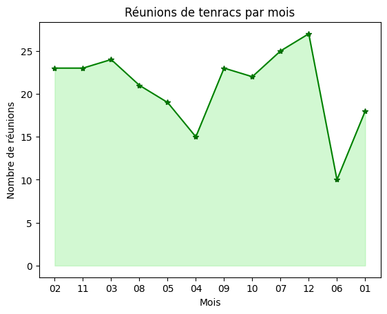

```python
import pandas
import matplotlib.pyplot as plt

def get_occur(d):
    r = {}
    for element in d:
        if element not in r:
            r[element] = 1
        else:
            r[element] += 1
    return r

table1 = pandas.read_csv("csv_output/Reunion.csv")
table1 = table1['date_reunion'].tolist()
retour = []
for element in table1:
    retour.append(element[21]+element[22])

resultat = get_occur(retour)

x = list(resultat.keys())
y = list(resultat.values())

plt.fill_between(x, y, color="lightgreen", alpha=0.4)

plt.title("Réunions de tenracs par mois")
plt.xlabel('Mois')
plt.ylabel('Nombre de réunions')

plt.plot(x, y, "*", color="darkgreen")
plt.plot(x,y, "green")
plt.show()
```

## V - Répartition des rangs au sein de la population tenrac

Les rangs sont des signes distinctifs qui servent à hiérarchiser les tenracs entre eux, il est donc intéréssant de chercher à savoir comment ils sont répartis dans la population tenrac car cela permet de mesurer la capacité des tenracs à évoluer.

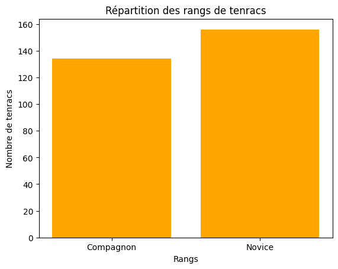

```python
import pandas
import matplotlib.pyplot as plt

def get_occur(d):
    r = {}
    for element in d:
        if element not in r:
            r[element] = 1
        else:
            r[element] += 1
    return r

table1 = pandas.read_csv("csv_output/Rang.csv")
table1 = table1['nom_rang'].tolist()
resultat = get_occur(table1)


x = list(resultat.keys())
y = list(resultat.values())

plt.title("Répartition des rangs de tenracs")
plt.xlabel('Rangs')
plt.ylabel('Nombre de tenracs')

plt.bar(x,y, color='orange')
plt.show()
```

On constate une répartition proche entre le nombre de Compagnons et de Novices bien que le nombre de novices soit légèrement plus élevé, cela laisse entendre que la majorité des tenracs ont un rang faible ce qui est logique.

## VI - Répartition des types de légumes acceptés par les tenracs

La variété de légumes acceptés par les tenracs est suffisamment importante pour dresser un aperçu des préférences de ces mêmes tenracs par types de légumes.

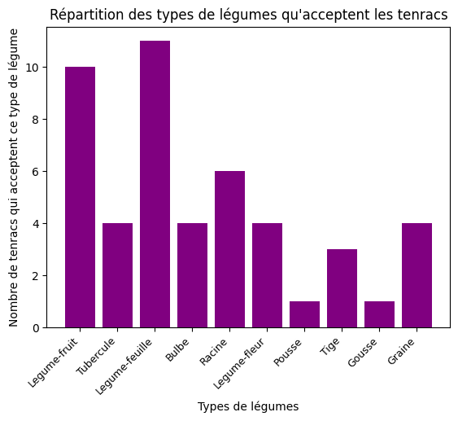

```python
import pandas
import matplotlib.pyplot as plt

def get_occur(d):
    r = {}
    for element in d:
        if element not in r:
            r[element] = 1
        else:
            r[element] += 1
    return r

table1 = pandas.read_csv("csv_output/Legume.csv")
table1 = table1['type_legume'].tolist()
resultat = get_occur(table1)


x = list(resultat.keys())
y = list(resultat.values())

plt.title("Répartition des types de légumes qu'acceptent les tenracs")
plt.xlabel('Types de légumes')
plt.ylabel('Nombre de tenracs qui acceptent ce type de légume')

plt.bar(x,y, color='purple')
plt.xticks(rotation=45, ha='right', fontsize=9)
plt.show()
```

On remarque que deux types de légumes sont particulièrement tolérés par les tenracs mangeurs de légumes, il s'agit des légumes-fruits (acceptés par 10 tenracs) et les légumes-feuille (acceptés par 11 tenracs).

## VII - Comparaison des premières lettres des noms et prénoms des tenracs

Bien que ces données ne soient pas importantes pour les tenracs en particulier, elles démontrent un certain lien entre les lettres utilisés pour les prénom et les noms.

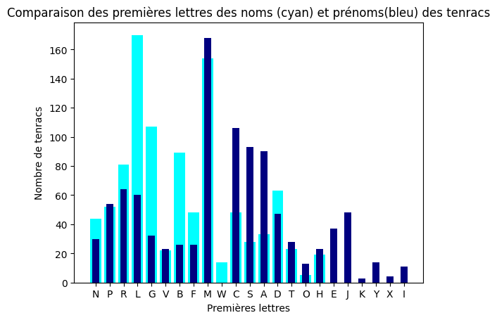

```python
import pandas
import matplotlib.pyplot as plt

def get_occur(d):
    r = {}
    for element in d:
        if element not in r:
            r[element] = 1
        else:
            r[element] += 1
    return r

table1 = pandas.read_csv("csv_output/Tenrac.csv")
table1 = table1['nom'].tolist()
table2 = []
for element in table1:
    table2.append(element[0])

table3 = pandas.read_csv("csv_output/Tenrac.csv")
table3 = table3['prenom'].tolist()
table4 = []
for element in table3:
    table4.append(element[0])

resultat1 = get_occur(table2)
resultat2 = get_occur(table4)

x1 = list(resultat1.keys())
y1 = list(resultat1.values())

x2 = list(resultat2.keys())
y2 = list(resultat2.values())

plt.title("Comparaison des premières lettres des noms (cyan) et prénoms(bleu) des tenracs")
plt.xlabel('Premières lettres')
plt.ylabel('Nombre de tenracs')

plt.bar(x1,y1,align='center', color='cyan')
plt.bar(x2,y2,color='navy',width=0.5)

plt.show()
```

On observe un rapprochement entre le nombre d'occurences des lettres P, V, M, T, O, H à la fois dans les prénoms et les noms des tenracs.

# Répartition du travail

- Aurele 30 % : Réalisation de la template des programmes responsable de la création des graphiques (3 et 7) + Aide globale
- Mathias 25 % : Réalisation des graphique 1 et 2 et du jeu de donné
- Adam 18 % : Réalisation du graphique 4 + aide de conversion en csv + graphique 6 + support de présentation
- Loïs 17 % : Réalisation du programme de conversion de données sql en fichier .csv
- Younes 10 % : Réalisation du graphique 5

30 + 25 + 18 + 17 + 10 = 100 ;)